# Reproducible Research: Peer Assessment 1

Benoit Séguin

2024-09-22

This document presents the steps necessary to analyze the activity data which shows the number of steps taken in 5 minute intervals

## Loading and preprocessing the data

To answer the question, we will first need to load the required libraries to execute the code

```r
library(dplyr)
library(tidyr)
library(lubridate)
```

Then we will load the activity.csv data using read.csv

```r
activity <- read.csv("activity.csv")
```

Finally, we will prepare the data to ensure we can analyze it properly

```r
activity$date = as.Date(activity$date,"%Y-%m-%d")
```

## What is mean total number of steps taken per day?

#### 1. Calculate the total number of steps taken per day, ignoring missing values as indicated.

```r
DailySteps <- activity %>% group_by(date) %>% summarize(Steps = sum(steps,na.rm = TRUE))
```

#### 2. Plot histogram

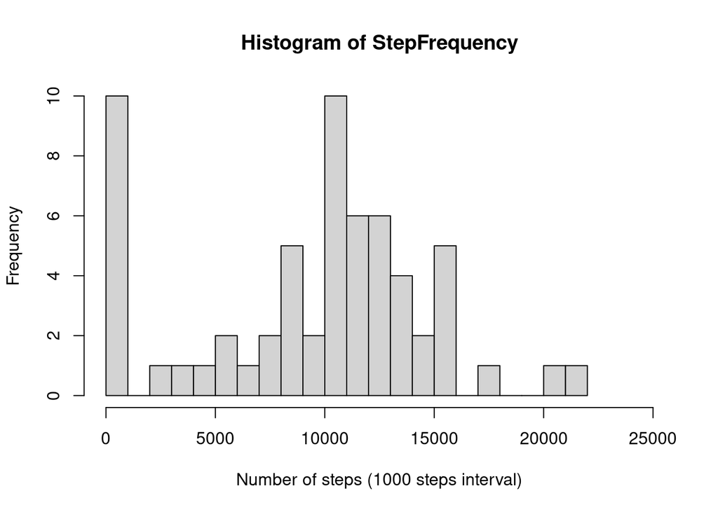

```r
StepFrequency <- DailySteps$Steps
hist(StepFrequency, breaks=25, xlim=c(0,25000), xlab = "Number of steps (1000 steps interval)")
```

#### 3. Calculate and report the mean and median of total number of steps

```r
MeanDailySteps <- mean(DailySteps$Steps, na.rm = TRUE)
MedianDailySteps <- median(DailySteps$Steps, na.rm = TRUE)
```

The daily steps mean is:

```r
print(MeanDailySteps)
```

```
## [1] 9354.23
```

The daily steps median is:

```r
print(MedianDailySteps)
```

```
## [1] 10395
```

## What is the average daily activity pattern?

#### 1. Timeseries plot of the average number of steps per interval

Sum the total number of steps per interval, then average by interval and plot, ignoring missing values as indicated.

```r
IntervalSteps <-
  activity %>% group_by(interval) %>%
  summarize(mean = mean(steps, na.rm = TRUE))
```

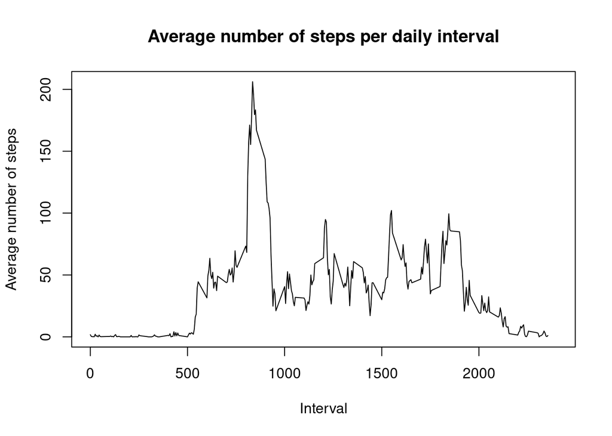

```r
plot(
  IntervalSteps$interval,IntervalSteps$mean,
  xlim=c(0,2400),
  main = "Average number of steps per daily interval",
  xlab = "Interval",
  ylab = "Average number of steps",
  type="l")
```

#### 2. Identify which 5 minute interval, on average, contains the maximum number of steps

Use the max function to identify all 5 minute intervals with the max average value.

```r
MaxInterval <-
  IntervalSteps[IntervalSteps$mean == max(IntervalSteps$mean), ]$interval
```

The interval with the max average is:

```r
print(MaxInterval)
```

```
## [1] 835
```

## Imputing missing values

#### 1. Calculate and report the total number of missing values

Use the function is.na to identify missing values

```r
sum(is.na(activity$steps))
```

```
## [1] 2304
```

```r
sum(is.na(activity$date))
```

```
## [1] 0
```

```r
sum(is.na(activity$interval))
```

```
## [1] 0
```

There are 2304 records with missing steps

#### 2. Impute interval mean for missing steps

Replicate Steps column and Impute interval mean to NA values

```r
activity$ImputedSteps <- activity$steps
activity <- activity %>%
  group_by(interval) %>%
  mutate(
    ImputedSteps = ifelse(is.na(ImputedSteps), mean(ImputedSteps, na.rm = TRUE),ImputedSteps))
```

Confirm no NA

```r
sum(is.na(activity$ImputedSteps))
```

```
## [1] 0
```

#### 3. Create a new dataset that is equal to the original dataset but with the missing data filled in.

Create new dataset

```r
activityNew <- activity[,c("ImputedSteps","date","interval")]
names(activityNew)[1] <- "steps"
head(activityNew)
```

```
## # A tibble: 6 x 3
## # Groups:   interval [6]
##    steps date       interval
##    <dbl> <date>        <int>
## 1 1.72   2012-10-01        0
## 2 0.340  2012-10-01        5
## 3 0.132  2012-10-01       10
## 4 0.151  2012-10-01       15
## 5 0.0755 2012-10-01       20
## 6 2.09   2012-10-01       25
```

#### 3. Recreate Q1 with activityNew. Are there differences in Mean and Median total number of steps taken per day

Repurpose code from Q1 with activityNew to create new histogram

```r
DailyStepsNew <- activityNew %>% group_by(date) %>% summarize(Steps = sum(steps,na.rm = TRUE))
```

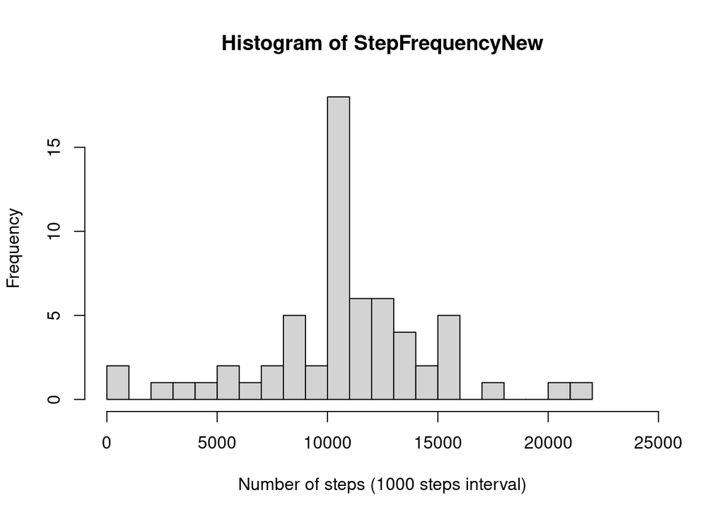

```r
StepFrequencyNew <- DailyStepsNew$Steps
hist(StepFrequencyNew, breaks=25, xlim=c(0,25000), xlab = "Number of steps (1000 steps interval)")
```

Calculate and report mean and median total number of steps

The new daily steps mean and median are:

```r
MeanDailyStepsNew <- mean(DailyStepsNew$Steps, na.rm = TRUE)
MedianDailyStepsNew <- median(DailyStepsNew$Steps, na.rm = TRUE)
print(MeanDailyStepsNew)
```

```
## [1] 10766.19
```

```r
print(MedianDailyStepsNew)
```

```
## [1] 10766.19
```

The impact of imputing missing data on the estimates of total daily has increased both the mean and median

## Are there differences in activity patterns between weekdays and weekends?

#### 1. Add weekday to the activityNew dataset

```r
activityNew$Day <- weekdays(activityNew$date)
```

Create factor variable to identify if weekday or weekend

```r
activityNew$Weekday <- factor(ifelse(wday(activityNew$date) %in% c(1,7),"Weekend","Weekday"))
```

#### 2. Timeseries panel plot

Time series panel plot for the 5 minute intervals and average number of steps taken, averaged accross all weekday or weekend days

```r
WeekdaySteps <-
  activityNew %>% group_by(Weekday,interval) %>%
  summarize(mean = mean(steps, na.rm = TRUE))
```

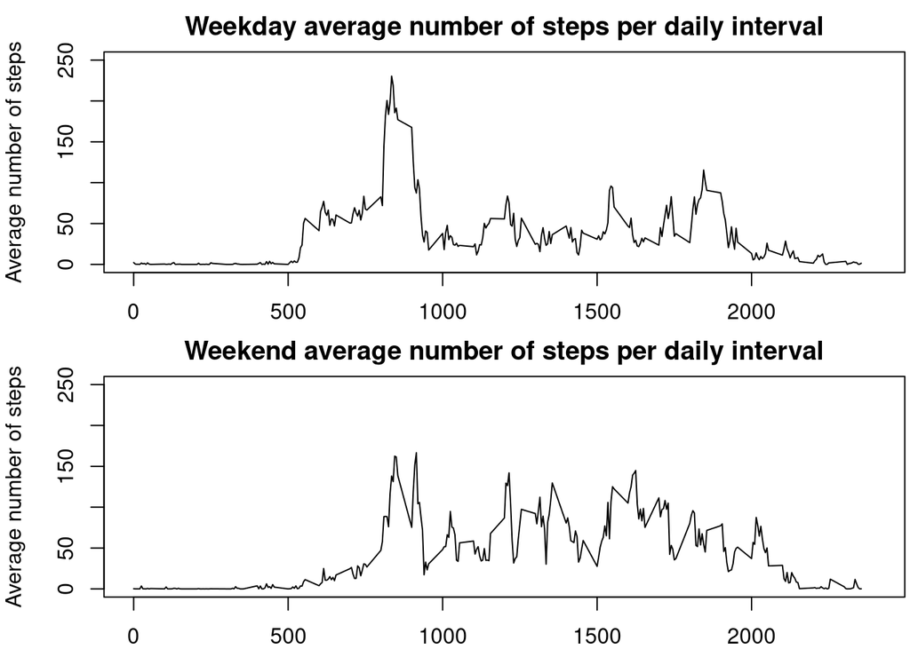

```r
par(mfrow = c(2, 1), mar=c(2,4,2,0.2))
plot(
  WeekdaySteps$interval[WeekdaySteps$Weekday == "Weekday"],
  WeekdaySteps$mean[WeekdaySteps$Weekday == "Weekday"],
  xlim=c(0,2400),
  ylim=c(0,250),
  main = "Weekday average number of steps per daily interval",
  xlab = "Interval",
  ylab = "Average number of steps",
  type="l")
plot(
  WeekdaySteps$interval[WeekdaySteps$Weekday == "Weekend"],
  WeekdaySteps$mean[WeekdaySteps$Weekday == "Weekend"],
  xlim=c(0,2400),
  ylim=c(0,250),
  main = "Weekend average number of steps per daily interval",
  xlab = "Interval",
  ylab = "Average number of steps",
  type="l")
```